# Sales Data Analysis and Strategic Recommendation

Earnest Ouma Andele

2025-10-01

# 1 📥 Loading libraries.

**Loading Necessary libraries**

```r
library(tidyverse)
library(ggplot2)
library(gridExtra)
library(dplyr)
library(grid)
library(scales)
library(ggtext)
library(ggrepel)
library(ggthemes)
library(lubridate)
library(tidyr)
```

# 2 📥 Loading and Preparing the Data.

## 2.1 Load the Data set.

**Read The Data set**

```r
data<- read.csv("C:/Users/Earnest/Desktop/School of Statistician/week16_time_series_dashboard_data.csv")
```

## 2.2 Convert date to proper format and extract day of the week.

```r
data$date <- as.Date(data$date)
data$day_of_week <- weekdays(data$date)
```

## 2.3 Preview Structure.

```r
glimpse(data)
```

```
## Rows: 5,000
## Columns: 13
## $ date             <date> 2024-01-01, 2024-01-01, 2024-01-01, 2024-01-01, 2024…
## $ region           <chr> "Nairobi", "Nairobi", "Nairobi", "Nairobi", "Nairobi"…
## $ product_category <chr> "Electronics", "Electronics", "Groceries", "Groceries…
## $ channel          <chr> "Online", "Store", "Online", "Store", "Online", "Stor…
## $ customer_segment <chr> "All", "All", "All", "All", "All", "All", "All", "All…
## $ orders           <int> 84, 83, 168, 152, 135, 113, 102, 103, 133, 119, 84, 7…
## $ units            <int> 156, 117, 153, 332, 154, 154, 172, 160, 231, 239, 146…
## $ revenue          <dbl> 37658.47, 28319.34, 2320.67, 4830.44, 5892.07, 5927.1…
## $ cost             <dbl> 28969.42, 21809.35, 1418.07, 2996.58, 3298.83, 3259.3…
## $ profit           <dbl> 8689.05, 6509.99, 902.60, 1833.86, 2593.25, 2667.86, …
## $ avg_order_value  <dbl> 448.32, 341.20, 13.81, 31.78, 43.64, 52.45, 101.65, 9…
## $ returns_rate     <dbl> 0.0452, 0.0354, 0.0244, 0.0277, 0.0338, 0.0485, 0.010…
## $ day_of_week      <chr> "Monday", "Monday", "Monday", "Monday", "Monday", "Mo…
```

## 2.4 Summary Statistics

```r
summary(data)
```

```
##       date               region          product_category     channel
##  Min.   :2024-01-01   Length:5000        Length:5000        Length:5000
##  1st Qu.:2024-01-25   Class :character   Class :character   Class :character
##  Median :2024-02-19   Mode  :character   Mode  :character   Mode  :character
##  Mean   :2024-02-19
##  3rd Qu.:2024-03-15
##  Max.   :2024-04-09
##  customer_segment       orders          units          revenue
##  Length:5000        Min.   : 56.0   Min.   : 40.0   Min.   : 1164
##  Class :character   1st Qu.: 97.0   1st Qu.:142.0   1st Qu.: 4546
##  Mode  :character   Median :115.0   Median :182.0   Median : 7334
##                     Mean   :119.6   Mean   :190.3   Mean   :12086
##                     3rd Qu.:136.0   3rd Qu.:228.0   3rd Qu.:12121
##                     Max.   :219.0   Max.   :494.0   Max.   :69935
##       cost             profit        avg_order_value   returns_rate
##  Min.   :  709.5   Min.   :  444.8   Min.   :  7.27   Min.   :0.00000
##  1st Qu.: 2496.3   1st Qu.: 1988.8   1st Qu.: 33.44   1st Qu.:0.02320
##  Median : 4115.6   Median : 3203.4   Median : 61.44   Median :0.03005
##  Mean   : 8310.4   Mean   : 3775.8   Mean   :125.18   Mean   :0.02993
##  3rd Qu.: 7143.7   3rd Qu.: 4792.3   3rd Qu.:110.94   3rd Qu.:0.03650
##  Max.   :53671.1   Max.   :16263.6   Max.   :730.22   Max.   :0.07480
##  day_of_week
##  Length:5000
##  Class :character
##  Mode  :character
##
##
##
```

**Explanation**

loaded the dataset and viewed its structure and summary. This helps in knowing the types of variables(categorical, numerical) and checks for missing values.

# 3 Sales & Demand Analysis.

## 3.1 Which regions recorded the highest number of orders in week 16?.

**Total Orders by Region**

```r
orders_by_region <- data %>%
  group_by(region) %>%
  summarise(total_orders = sum(orders)) %>%
  arrange(desc(total_orders))

print(orders_by_region)
```

```
## # A tibble: 5 × 2
##   region      total_orders
##   <chr>              <int>
## 1 Central           120378
## 2 Nairobi           119865
## 3 Rift Valley       119505
## 4 Coast             119330
## 5 Western           118838
```

**Visualization**

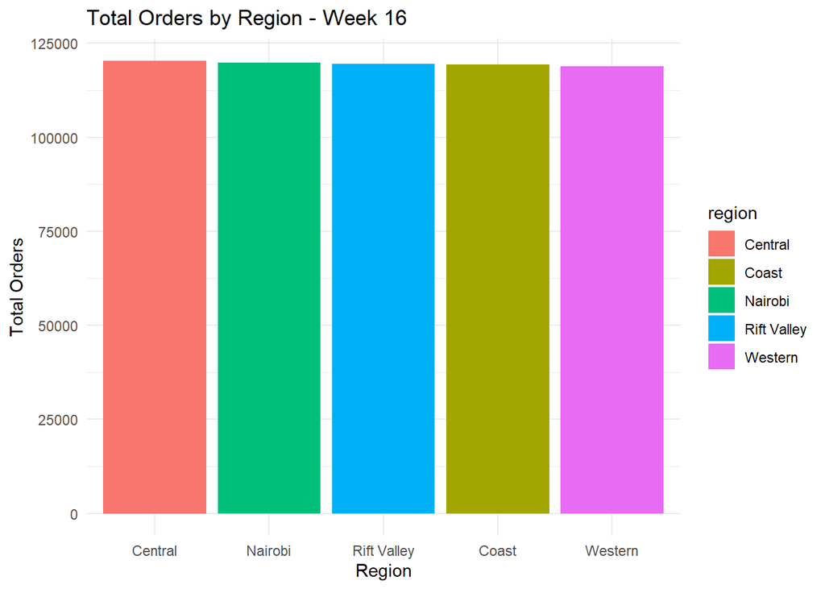

```r
ggplot(orders_by_region, aes(x = reorder(region, -total_orders), y = total_orders, fill = region)) +
  geom_bar(stat = "identity") +
  labs(title = "Total Orders by Region - Week 16",
       x = "Region", y = "Total Orders") +
  theme_minimal()
```

## 3.2 How do orders differ between Online and Store chanenels for each product Category?

```r
orders_by_category_channel <- data %>%
  group_by(product_category, channel) %>%
  summarise(total_orders = sum(orders)) %>%
  spread(channel, total_orders) %>%
  mutate(difference = Online - Store)


print(orders_by_category_channel)
```

```
## # A tibble: 5 × 4
## # Groups:   product_category [5]
##   product_category Online Store difference
##   <chr>             <int> <int>      <int>
## 1 Apparel           65791 60242       5549
## 2 Beauty            60499 54764       5735
## 3 Electronics       43847 39904       3943
## 4 Groceries         87893 79613       8280
## 5 Home              55230 50133       5097
```

**Visualization**

[figure not shown]

```r
ggplot(data, aes(x = product_category, y = orders, fill = channel)) +
  geom_bar(stat = "identity", position = "dodge") +
  labs(title = "Orders by Product Category and Channel",
       x = "Product Category", y = "Total Orders") +
  theme_minimal() +
  theme(axis.text.x = element_text(angle = 45, hjust = 1))
```

## 3.3 Which product category had the most units sold, and in which region?

```r
units_by_category_region <- data %>%

  group_by(product_category, region) %>%
  summarise(total_units = sum(units)) %>%
  arrange(desc(total_units))

print(head(units_by_category_region, 10))
```

```
## # A tibble: 10 × 3
## # Groups:   product_category [2]
##    product_category region      total_units
##    <chr>            <chr>             <int>
##  1 Groceries        Nairobi           52861
##  2 Groceries        Central           52671
##  3 Groceries        Coast             52598
##  4 Groceries        Rift Valley       52453
##  5 Groceries        Western           52016
##  6 Apparel          Rift Valley       41773
##  7 Apparel          Coast             41651
##  8 Apparel          Nairobi           41627
##  9 Apparel          Central           40381
## 10 Apparel          Western           38384
```

**Find the maximum**

```r
max_units <- units_by_category_region[1, ]
cat("Category with most units:", max_units$product_category,
    "in region:", max_units$region,
    "with", max_units$total_units, "units\n")
```

```
## Category with most units: Groceries in region: Nairobi with 52861 units
```

## 3.4 Are there noticeable daily sales trends?

```r
daily_trends <- data %>%
  group_by(date, day_of_week) %>%
  summarise(daily_orders = sum(orders),
            daily_revenue = sum(revenue),
            daily_units = sum(units))


print(daily_trends)
```

```
## # A tibble: 100 × 5
## # Groups:   date [100]
##    date       day_of_week daily_orders daily_revenue daily_units
##    <date>     <chr>              <int>         <dbl>       <int>
##  1 2024-01-01 Monday              6045       595548.        9141
##  2 2024-01-02 Tuesday             5957       622289.        9926
##  3 2024-01-03 Wednesday           5912       592311.        9207
##  4 2024-01-04 Thursday            5909       640586.        9856
##  5 2024-01-05 Friday              5968       552713.        9431
##  6 2024-01-06 Saturday            5865       617710.        9410
##  7 2024-01-07 Sunday              6002       600760.        9808
##  8 2024-01-08 Monday              5965       630601.        9444
##  9 2024-01-09 Tuesday             6003       626180.        9798
## 10 2024-01-10 Wednesday           6022       561683.        9597
## # ℹ 90 more rows
```

**Visualization**

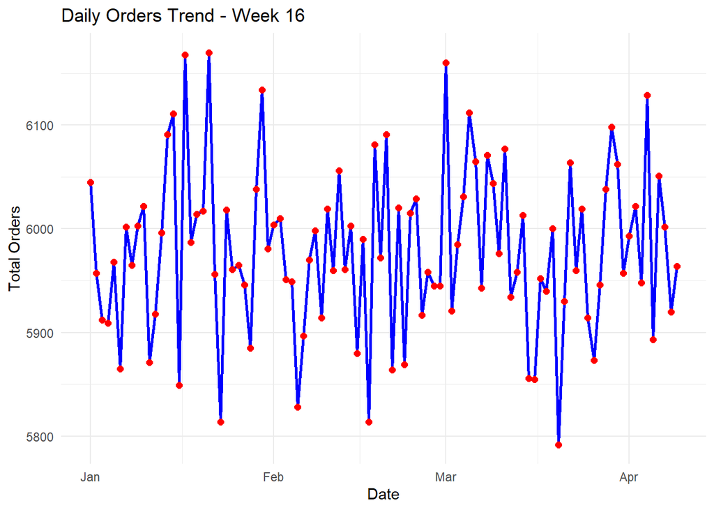

```r
ggplot(daily_trends, aes(x = date, y = daily_orders)) +
  geom_line(color = "blue", size = 1) +
  geom_point(color = "red", size = 2) +
  labs(title = "Daily Orders Trend - Week 16",
       x = "Date", y = "Total Orders") +
  theme_minimal()
```

**Explanation**

“What’s selling, where, and when?” Measures basic business activity - orders, units sold, and daily patterns across regions and channels.

# 4 Revenue & Profitability

## 4.1 Which region generated the highest total revenue?

```r
revenue_by_region <- data %>%
  group_by(region) %>%
  summarise(total_revenue = sum(revenue)) %>%

  arrange(desc(total_revenue))

print(revenue_by_region)
```

```
## # A tibble: 5 × 2
##   region      total_revenue
##   <chr>               <dbl>
## 1 Nairobi         12274034.
## 2 Coast           12191615.
## 3 Central         12005573.
## 4 Rift Valley     11993027.
## 5 Western         11966350.
```

**Visualization**

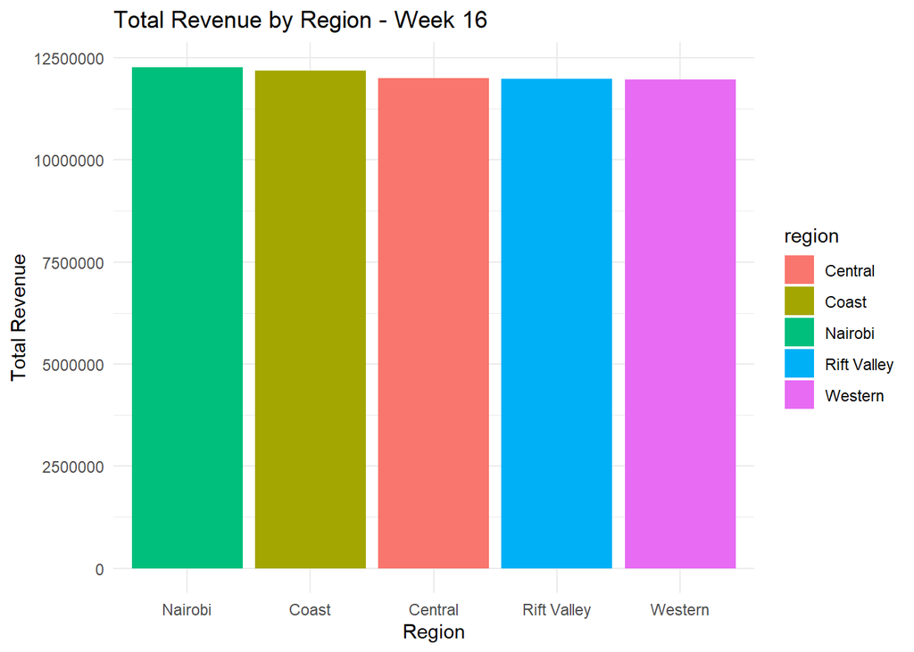

```r
ggplot(revenue_by_region, aes(x = reorder(region, -total_revenue), y = total_revenue, fill = region)) +
  geom_bar(stat = "identity") +
  labs(title = "Total Revenue by Region - Week 16",
       x = "Region", y = "Total Revenue") +
  theme_minimal()
```

## 4.2 Most profitable product category

```r
profit_by_category <- data %>%
  group_by(product_category) %>%
  summarise(total_profit = sum(profit),
            profit_margin = sum(profit) /

sum(revenue) * 100) %>%
  arrange(desc(total_profit))

print(profit_by_category)
```

```
## # A tibble: 5 × 3
##   product_category total_profit profit_margin
##   <chr>                   <dbl>         <dbl>
## 1 Electronics          7424296.          22.0
## 2 Home                 3983610.          40.0
## 3 Apparel              3667551.          45.0
## 4 Beauty               2304960.          50.0
## 5 Groceries            1498434.          38.0
```

## 4.3 Profit margin across categories and channels

```r
margin_by_category_channel <- data %>%
  group_by(product_category, channel) %>%
  summarise(profit_margin = sum(profit) / sum(revenue) * 100) %>%
  spread(channel, profit_margin)

print(margin_by_category_channel)
```

```
## # A tibble: 5 × 3
## # Groups:   product_category [5]
##   product_category Online Store
##   <chr>             <dbl> <dbl>
## 1 Apparel            45.0  45.0
## 2 Beauty             50.0  50.0
## 3 Electronics        21.9  22.0
## 4 Groceries          38.0  38.0
## 5 Home               40.0  40.0
```

**Visualization**

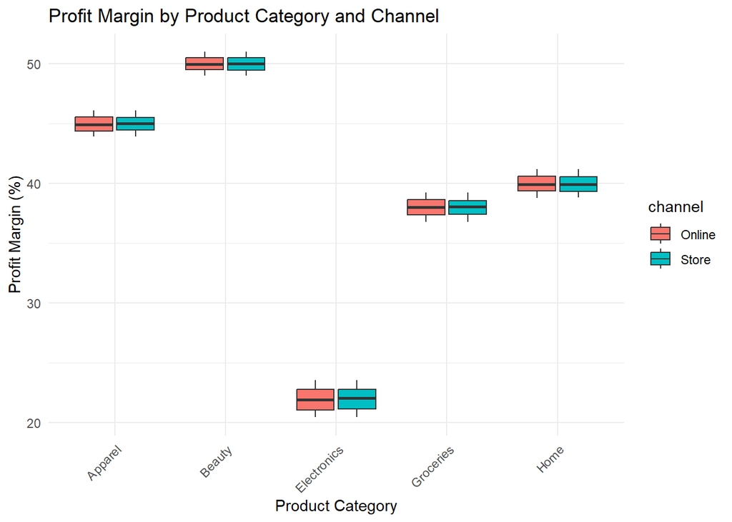

```r
ggplot(data, aes(x = product_category, y = profit/revenue*100, fill = channel)) +
  geom_boxplot() +

  labs(title = "Profit Margin by Product Category and Channel",
       x = "Product Category", y = "Profit Margin (%)") +
  theme_minimal() +
  theme(axis.text.x = element_text(angle = 45, hjust = 1))
```

## 4.4 Online vs Store Average Order Value (AOV)

```r
aov_comparison <- data %>%
  group_by(channel) %>%
  summarise(avg_order_value = mean(avg_order_value),
            total_orders = sum(orders))

print(aov_comparison)
```

```
## # A tibble: 2 × 3
##   channel avg_order_value total_orders
##   <chr>             <dbl>        <int>
## 1 Online             126.       313260
## 2 Store              125.       284656
```

**Statistical test**

```r
t_test_result <- t.test(avg_order_value ~ channel, data = data)
print(t_test_result)
```

```
##
##  Welch Two Sample t-test
##
## data:  avg_order_value by channel
## t = 0.20195, df = 4997.5, p-value = 0.84
## alternative hypothesis: true difference in means between group Online and group Store is not equal to 0
## 95 percent confidence interval:
##  -7.388463  9.085471
## sample estimates:
## mean in group Online  mean in group Store
##             125.6027             124.7542
```

**Explanation**

“Where is the money coming from and how profitable is it?” Tracks actual money earned and profit margins, showing which areas truly drive your bottom line.

# 5 Customer Behavior & Segmentation

## 5.1 Customer segment revenue contribution

**Since all data is “All” segment, we’ll analyze regional preferences instead**

```r
segment_analysis <- data %>%
  group_by(region, product_category) %>%
  summarise(total_revenue = sum(revenue),
            total_orders = sum(orders)) %>%
  arrange(region, desc(total_revenue))

print(segment_analysis)
```

```
## # A tibble: 25 × 4
## # Groups:   region [5]
##    region  product_category total_revenue total_orders
##    <chr>   <chr>                    <dbl>        <int>
##  1 Central Electronics           6721137.        16920
##  2 Central Home                  1975093.        21269
##  3 Central Apparel               1618908.        25318
##  4 Central Beauty                 900683.        23170
##  5 Central Groceries              789752.        33701
##  6 Coast   Electronics           6847488.        16622
##  7 Coast   Home                  1989145.        21008
##  8 Coast   Apparel               1665256.        25265
##  9 Coast   Beauty                 901509         22941
## 10 Coast   Groceries              788216.        33494
## # ℹ 15 more rows
```

## 5.2 Regional category preferences

```r
regional_preferences <- data %>%
  group_by(region, product_category) %>%
  summarise(revenue_share = sum(revenue)) %>%
  group_by(region) %>%
  mutate(total_region_revenue = sum(revenue_share),
         percentage = revenue_share / total_region_revenue * 100) %>%
  arrange(region, desc(percentage))

print(regional_preferences)
```

```
## # A tibble: 25 × 5
## # Groups:   region [5]
##    region  product_category revenue_share total_region_revenue percentage
##    <chr>   <chr>                    <dbl>                <dbl>      <dbl>
##  1 Central Electronics           6721137.            12005573.      56.0
##  2 Central Home                  1975093.            12005573.      16.5
##  3 Central Apparel               1618908.            12005573.      13.5
##  4 Central Beauty                 900683.            12005573.       7.50
##  5 Central Groceries              789752.            12005573.       6.58
##  6 Coast   Electronics           6847488.            12191615.      56.2
##  7 Coast   Home                  1989145.            12191615.      16.3
##  8 Coast   Apparel               1665256.            12191615.      13.7
##  9 Coast   Beauty                 901509             12191615.       7.39
## 10 Coast   Groceries              788216.            12191615.       6.47
## # ℹ 15 more rows
```

**Heatmap visualization**

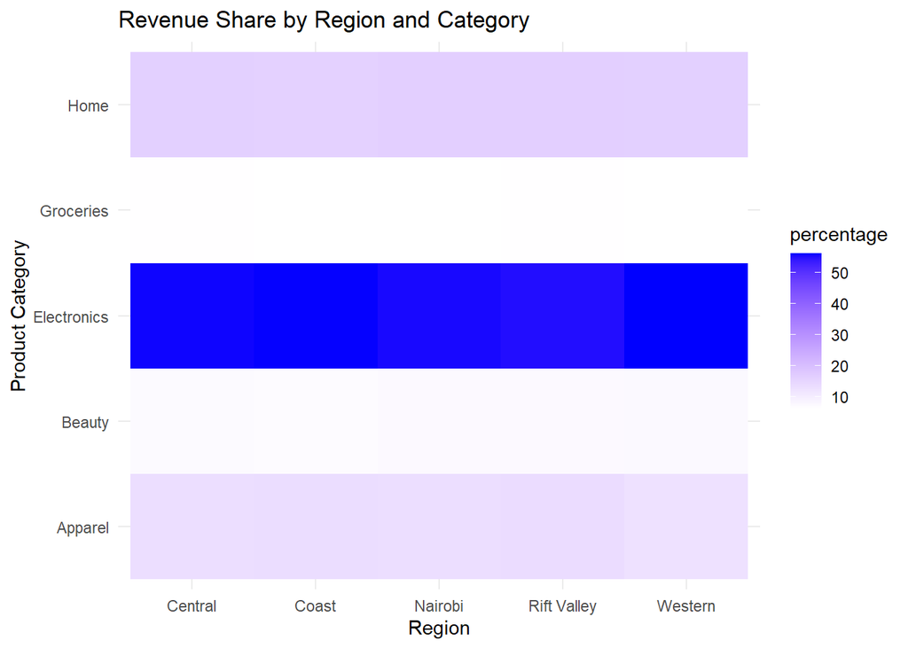

```r
ggplot(regional_preferences, aes(x = region, y = product_category, fill = percentage)) +
  geom_tile() +
  scale_fill_gradient(low = "white", high = "blue") +

  labs(title = "Revenue Share by Region and Category",
       x = "Region", y = "Product Category") +
  theme_minimal()
```

## 5.3 Average Order Value insights

```r
aov_analysis <- data %>%
  group_by(product_category, channel) %>%
  summarise(avg_order_value = mean(avg_order_value),
            count_orders = n()) %>%
  arrange(desc(avg_order_value))

print(aov_analysis)
```

```
## # A tibble: 10 × 4
## # Groups:   product_category [5]
##    product_category channel avg_order_value count_orders
##    <chr>            <chr>             <dbl>        <int>
##  1 Electronics      Online            405.           500
##  2 Electronics      Store             401.           500
##  3 Home             Store              95.0          500
##  4 Home             Online             94.4          500
##  5 Apparel          Online             65.1          500
##  6 Apparel          Store              64.4          500
##  7 Beauty           Store              40.0          500
##  8 Beauty           Online             39.9          500
##  9 Groceries        Store              23.5          500
## 10 Groceries        Online             23.5          500
```

**Explanation**

“Who’s buying what and how do they shop?” Analyzes customer preferences, spending patterns, and regional tastes to understand your market.

# 6 Operational Efficiency & Costs

## 6.1 Highest cost-to-revenue ratio

```r
cost_efficiency <- data %>%
  group_by(product_category) %>%
  summarise(total_revenue = sum(revenue),
            total_cost = sum(cost),
            cost_ratio = sum(cost) / sum(revenue) * 100) %>%
  arrange(desc(cost_ratio))

print(cost_efficiency)
```

```
## # A tibble: 5 × 4
##   product_category total_revenue total_cost cost_ratio
##   <chr>                    <dbl>      <dbl>      <dbl>
## 1 Electronics          33759536.  26335239.       78.0
## 2 Groceries             3940701.   2442267.       62.0
## 3 Home                  9967433.   5983823.       60.0
## 4 Apparel               8154963.   4487413.       55.0
## 5 Beauty                4607966.   2303006.       50.0
```

## 6.2 Operational costs by region and channel

```r
operational_costs <- data %>%
  group_by(region, channel) %>%
  summarise(cost_per_revenue = sum(cost) / sum(revenue) * 100,
            revenue = sum(revenue),

            cost = sum(cost)) %>%
  arrange(desc(cost_per_revenue))

print(operational_costs)
```

```
## # A tibble: 10 × 5
## # Groups:   region [5]
##    region      channel cost_per_revenue  revenue     cost
##    <chr>       <chr>              <dbl>    <dbl>    <dbl>
##  1 Coast       Online              69.0 6478836. 4471201.
##  2 Western     Store               68.9 5705360. 3931360.
##  3 Nairobi     Online              68.9 6517594. 4488618.
##  4 Central     Store               68.9 5742797. 3954050.
##  5 Central     Online              68.8 6262776. 4309562.
##  6 Rift Valley Store               68.7 5809392. 3988714.
##  7 Western     Online              68.7 6260990. 4298290.
##  8 Rift Valley Online              68.6 6183636. 4243538.
##  9 Coast       Store               68.6 5712779. 3919036.
## 10 Nairobi     Store               68.6 5756440. 3947380.
```

## 6.3 Low profit despite high revenue

```r
profitability_analysis <- data %>%
  group_by(product_category) %>%
  summarise(total_revenue = sum(revenue),
            total_profit = sum(profit),
            profit_margin = sum(profit) / sum(revenue) * 100,
            profit_per_order = sum(profit) / sum(orders)) %>%
  arrange(profit_margin)

print(profitability_analysis)
```

```
## # A tibble: 5 × 5
##   product_category total_revenue total_profit profit_margin profit_per_order
##   <chr>                    <dbl>        <dbl>         <dbl>            <dbl>
## 1 Electronics          33759536.     7424296.          22.0            88.6
## 2 Groceries             3940701.     1498434.          38.0             8.95
## 3 Home                  9967433.     3983610.          40.0            37.8
## 4 Apparel               8154963.     3667551.          45.0            29.1
## 5 Beauty                4607966.     2304960.          50.0            20.0
```

**Explanation**

“How efficiently are we running the business?” Examines cost structures and identifies areas where the spending is too much relative to earning.

# 7 Returns & Risk Analysis

## 7.1 Highest returns rate by category

```r
returns_analysis <- data %>%
  group_by(product_category) %>%
  summarise(avg_returns_rate = mean(returns_rate) * 100,
            total_units = sum(units)) %>%
  arrange(desc(avg_returns_rate))

print(returns_analysis)
```

```
## # A tibble: 5 × 3
##   product_category avg_returns_rate total_units
##   <chr>                       <dbl>       <int>
## 1 Home                         3.05      166108
## 2 Apparel                      3.00      203816
## 3 Groceries                    2.99      262599
## 4 Beauty                       2.98      184197
## 5 Electronics                  2.95      134771
```

## 7.2 Correlation between returns rate and AOV

```r
correlation_test <- cor.test(data$returns_rate, data$avg_order_value)

print(correlation_test)
```

```
##
##  Pearson's product-moment correlation
##
## data:  data$returns_rate and data$avg_order_value
## t = -0.79232, df = 4998, p-value = 0.4282
## alternative hypothesis: true correlation is not equal to 0
## 95 percent confidence interval:
##  -0.03891379  0.01651784
## sample estimates:
##         cor
## -0.01120659
```

**Scatter plot**

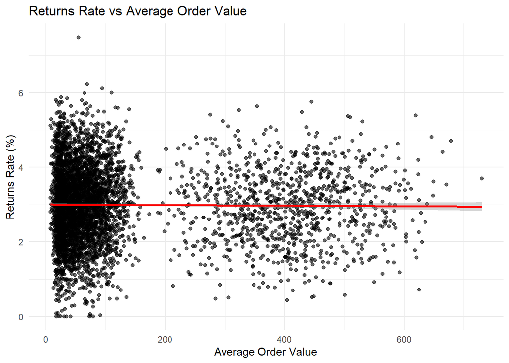

```r
ggplot(data, aes(x = avg_order_value, y = returns_rate * 100)) +
  geom_point(alpha = 0.6) +
  geom_smooth(method = "lm", color = "red") +
  labs(title = "Returns Rate vs Average Order Value",
       x = "Average Order Value", y = "Returns Rate (%)") +
  theme_minimal()
```

## 7.3 Online vs Store returns comparison

```r
returns_by_channel <- data %>%
  group_by(channel) %>%
  summarise(avg_returns_rate = mean(returns_rate) * 100,

            total_orders = sum(orders))

print(returns_by_channel)
```

```
## # A tibble: 2 × 3
##   channel avg_returns_rate total_orders
##   <chr>              <dbl>        <int>
## 1 Online              3.00       313260
## 2 Store               2.98       284656
```

**Statistical test**

```r
t_test_returns <- t.test(returns_rate ~ channel, data = data)
print(t_test_returns)
```

```
##
##  Welch Two Sample t-test
##
## data:  returns_rate by channel
## t = 0.61284, df = 4996.5, p-value = 0.54
## alternative hypothesis: true difference in means between group Online and group Store is not equal to 0
## 95 percent confidence interval:
##  -0.0003820916  0.0007296116
## sample estimates:
## mean in group Online  mean in group Store
##           0.03001216           0.02983840
```

**Explanation**

“Where are we losing money and why?” Focuses on product returns and risks that eat into profits, highlighting quality or customer satisfaction issues.

# 8 Trend & Strategic Insights

## 8.1 Emerging trends

**Daily trends by category**

```r
daily_category_trends <- data %>%
  group_by(date, product_category) %>%
  summarise(daily_revenue = sum(revenue),
            daily_orders = sum(orders)) %>%
  arrange(date, product_category)

print(daily_category_trends)
```

```
## # A tibble: 500 × 4
## # Groups:   date [100]
##    date       product_category daily_revenue daily_orders
##    <date>     <chr>                    <dbl>        <int>
##  1 2024-01-01 Apparel                 79060.         1290
##  2 2024-01-01 Beauty                  45033.         1130
##  3 2024-01-01 Electronics            344369.          831
##  4 2024-01-01 Groceries               37082.         1684
##  5 2024-01-01 Home                    90004.         1110
##  6 2024-01-02 Apparel                 74526.         1244
##  7 2024-01-02 Beauty                  50093.         1138
##  8 2024-01-02 Electronics            360401.          817
##  9 2024-01-02 Groceries               45446.         1738
## 10 2024-01-02 Home                    91824.         1020
## # ℹ 490 more rows
```

**Visualization**

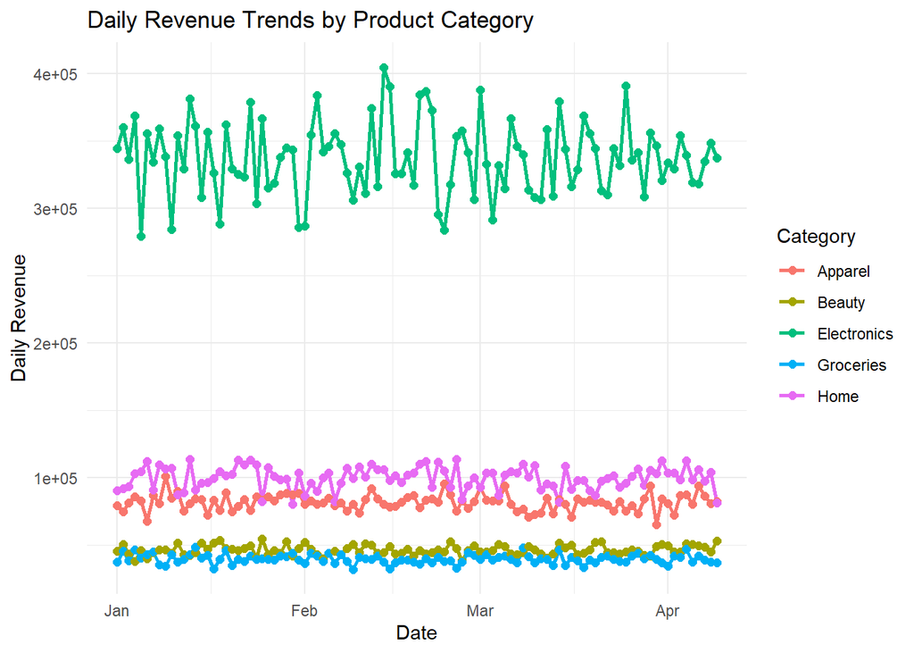

```r
ggplot(daily_category_trends, aes(x = date, y = daily_revenue, color = product_category, group = product_category)) +
  geom_line(size = 1) +
  geom_point(size = 2) +
  labs(title = "Daily Revenue Trends by Product Category",
       x = "Date", y = "Daily Revenue", color = "Category") +
  theme_minimal()
```

## 8.2 Priority region-product-channel combinations

```r
priority_combinations <- data %>%
  group_by(region, product_category, channel) %>%

  summarise(total_profit = sum(profit),
            profit_margin = sum(profit) / sum(revenue) * 100,
            total_orders = sum(orders)) %>%
  arrange(desc(total_profit))

print(head(priority_combinations, 10))
```

```
## # A tibble: 10 × 6
## # Groups:   region, product_category [5]
##    region      product_category channel total_profit profit_margin total_orders
##    <chr>       <chr>            <chr>          <dbl>         <dbl>        <int>
##  1 Coast       Electronics      Online       808051.          22.0         8762
##  2 Nairobi     Electronics      Online       803580.          21.9         8820
##  3 Western     Electronics      Online       767665.          22.0         8717
##  4 Central     Electronics      Online       762216.          21.9         8740
##  5 Rift Valley Electronics      Online       750272.          22.0         8808
##  6 Western     Electronics      Store        718355.          22.1         7822
##  7 Central     Electronics      Store        709950.          21.9         8180
##  8 Rift Valley Electronics      Store        708912.          22.0         8052
##  9 Coast       Electronics      Store        700489.          22.1         7860
## 10 Nairobi     Electronics      Store        694806.          22.0         7990
```

## 8.3 Cost reduction and profitability recommendations

**Identify improvement opportunities**

```r
improvement_opportunities <- data %>%
  group_by(product_category, region) %>%
  summarise(total_revenue = sum(revenue),
            total_profit = sum(profit),
            profit_margin = sum(profit) / sum(revenue) * 100,
            avg_returns = mean(returns_rate) * 100,

            cost_ratio = sum(cost) / sum(revenue) * 100) %>%
  arrange(profit_margin)

print(improvement_opportunities)
```

```
## # A tibble: 25 × 7
## # Groups:   product_category [5]
##    product_category region  total_revenue total_profit profit_margin avg_returns
##    <chr>            <chr>           <dbl>        <dbl>         <dbl>       <dbl>
##  1 Electronics      Central      6721137.     1472167.          21.9        2.92
##  2 Electronics      Nairobi      6832198.     1498386.          21.9        2.92
##  3 Electronics      Rift V…      6626002.     1459183.          22.0        2.98
##  4 Electronics      Coast        6847488.     1508540.          22.0        2.99
##  5 Electronics      Western      6732711.     1486020.          22.1        2.96
##  6 Groceries        Coast         788216.      298818.          37.9        2.98
##  7 Groceries        Nairobi       793182.      301733.          38.0        3.00
##  8 Groceries        Central       789752.      300479.          38.0        3.10
##  9 Groceries        Western       781171.      297301.          38.1        2.87
## 10 Groceries        Rift V…       788380.      300103.          38.1        3.01
## # ℹ 15 more rows
## # ℹ 1 more variable: cost_ratio <dbl>
```

**Summary recommendations**

```r
cat("\n=== STRATEGIC RECOMMENDATIONS ===\n")
```

```
##
## === STRATEGIC RECOMMENDATIONS ===
```

```r
cat("1. Focus on high-margin categories:",
    profit_by_category$product_category[1], "and",
    profit_by_category$product_category[2], "\n")
```

[output not shown]

```r
cat("2. Optimize costs in:",
    cost_efficiency$product_category[1], "category\n")
```

```
## 2. Optimize costs in: Electronics category
```

```r
cat("3. Address high returns in:",
    returns_analysis$product_category[1], "category\n")
```

```
## 3. Address high returns in: Home category
```

```r
cat("4. Prioritize region:",
    revenue_by_region$region[1], "for

expansion\n")
```

```
## 4. Prioritize region: Nairobi for
##
## expansion
```

```r
cat("5. Channel strategy: Consider",
    ifelse(aov_comparison$avg_order_value[1] > aov_comparison$avg_order_value[2],
           "increasing online presence", "strengthening store operations"), "\n")
```

```
## 5. Channel strategy: Consider increasing online presence
```

**Explanation**

“What should be done next?” Uses all the data to spot patterns and provide actionable recommendations for future strategy.

# 9 Final Summary Report

## 9.1 A comprehensive summary:

**Generate executive summary**

```r
cat("\n=== WEEK 16 PERFORMANCE SUMMARY ===\n\n")
```

```
##
## === WEEK 16 PERFORMANCE SUMMARY ===
```

```r
cat("TOP PERFORMERS:\n")
```

```
## TOP PERFORMERS:
```

```r
cat("- Highest Revenue Region:", revenue_by_region$region[1], "($",


round(revenue_by_region$total_revenue[1], 0), ")\n")
```

```
## - Highest Revenue Region: Nairobi ($ 12274034 )
```

```r
cat("- Most Profitable Category:", profit_by_category$product_category[1],
    "($", round(profit_by_category$total_profit[1], 0), ")\n")
```

```
## - Most Profitable Category: Electronics ($ 7424296 )
```

```r
cat("- Most Units Sold:", max_units$product_category, "in", max_units$region,
    "(", max_units$total_units, "units)\n\n")
```

```
## - Most Units Sold: Groceries in Nairobi ( 52861 units)
```

```r
cat("KEY INSIGHTS:\n")
```

```
## KEY INSIGHTS:
```

```r
cat("- Online vs Store AOV: $", round(aov_comparison$avg_order_value[1], 2),
    "vs $", round(aov_comparison$avg_order_value[2], 2), "\n")
```

```
## - Online vs Store AOV: $ 125.6 vs $ 124.75
```

```r
cat("- Returns Rate Difference:", round(abs(diff(returns_by_channel$avg_returns_rate)), 2),

    "% between channels\n")
```

```
## - Returns Rate Difference: 0.02 % between channels
```

```r
cat("- Best Profit Margin:", round(max(profit_by_category$profit_margin), 2), "%\n")
```

```
## - Best Profit Margin: 50.02 %
```

```r
cat("- Worst Profit Margin:", round(min(profit_by_category$profit_margin), 2), "%\n\n")
```

```
## - Worst Profit Margin: 21.99 %
```

```r
cat("RECOMMENDATIONS:\n")
```

```
## RECOMMENDATIONS:
```

```r
cat("1. Resource Allocation: Focus on", priority_combinations$region[1], "-",
    priority_combinations$product_category[1], "-",
    priority_combinations$channel[1], "combination\n")
```

```
## 1. Resource Allocation: Focus on Coast - Electronics - Online combination
```

```r
cat("2. Cost Optimization: Review", cost_efficiency$product_category[1],
    "category operations\n")
```

```
## 2. Cost Optimization: Review Electronics category operations
```

```r
cat("3. Returns Management: Implement strategies for",
    returns_analysis$product_category[1], "category\n")
```

```
## 3. Returns Management: Implement strategies for Home category
```

```r
cat("4. Channel Strategy: Balance online/store based on regional preferences\n")
```

```
## 4. Channel Strategy: Balance online/store based on regional preferences
```